# 22_Descriptives

# Exercises

## 1

Though this does not apply only to calculating Cohen’s *d*, let us use this as an example. As you will learn more about `R` and the `R` community, you will get to realize that one thing (operation) may be done in multiple ways. A quick search on `R` documentation reveals two additional packages that have functions to calculate Cohen’s *d*.

Use the packages `lsr` and `effsize` and calculate the Cohen’s *d* for the same “experimental” setting as above, `sex` as the grouping variable and `pv22` as the outcome of interest.

Remember to first install (if needed) the packages and instruct `R` from which package to call the function to calculate Cohen’s *d*!

Read the package instructions before applying the functions, otherwise you might get some weird results that can be difficult to explain.

Read [here](https://www.rdocumentation.org/packages/lsr/versions/0.5.2/topics/cohensD) for `lsr` package. Read [here](https://www.rdocumentation.org/packages/effsize/versions/0.8.1/topics/cohen.d) for `effsize` package.

```r
## installs packages
if (!require(lsr)) {
    install.packages("lsr")
    require(lsr)
}
if (!require(effsize)) {
    install.packages("effsize")
    require(effsize)
}
## activates packages
library(lsr)
library(effsize)

## calculates Cohen's d with lsr package
###
## calculating Cohen's d this ways requires that you first manipulate the data, such that
lsr_cohen_d_wrong <- lsr::cohensD(x=df_allbus$sex,
                            y=df_allbus$pv22)


## the richt way, which requires extra work
temp_lsr_df <- df_allbus %>%
  # selects only the variables of interest
  select(c("sex","pv22")) %>%
  # adds a unique identifier columns (useful for next step)
  mutate(rn=row_number()) %>%
  # transforms data into wide format, such that one column is for men and one for women
  pivot_wider(names_from = sex,
                values_from = pv22)

## now calculates cohen's d with lsr package
lsr_cohen_d_right <- lsr::cohensD(temp_lsr_df$`1`,temp_lsr_df$`2`)

## calculates Cohen's d with effsize package
###
## like with the lsr package, the data needs to be transformed into wide format
temp_effsize_df <- df_allbus %>%
  # selects only the variables of interest
  select(c("sex","pv22")) %>%
  # adds a unique identifier columns (useful for next step)
  mutate(rn=row_number()) %>%
  # transforms data into wide format, such that one column is for men and one for women
  pivot_wider(names_from = sex,
                values_from = pv22)

## now calculates Cohen's d with effsize package
effsize_cohen_d_right <- effsize::cohen.d(temp_effsize_df$`1`, temp_effsize_df$`2`,
                                          na.rm=TRUE)
```

Inspect if all approaches give identical results.

```r
# psych package
cohen_d_sex_pv22$cohen.d[2]
```

```
## [1] 0.1793207
```

```r
# lsr package
lsr_cohen_d_right
```

```
## [1] 0.1792663
```

```r
# effsize package
effsize_cohen_d_right$estimate
```

```
## [1] -0.1792663
```

## 2

Let’s imagine we expect that a specific political orientation associates with an intention to vote for one of the three parties forming the current German government. We might also expect that an intention to vote for one of the three parties might be aggregated into an intetion to vote for the current government.

So, let’s say, we want to create a scatter plot with trend lines for inspecting association between `pa01` (Self-placement on the left-right political spectrum) and an index termed “Intention to vote for the current German government” that is formed by aggregating the intentions to vote for SPD (`pv20`), FDP (`pv21`), and the Greens (`pv22`).

Then we want to group observations after the variable `work` (Participant employment status).

```r
## to be deleted, this is key to exercise
exer_22_longdf <- df_allbus %>%
  mutate(vote_int=(pv20+pv21+pv22)/3) %>% # calculates aggregated index
  select(work,pa01,vote_int) %>% # creates a short data frame with the mentioned variables
  group_by(work) # groups for work

# inspects the data frame
head(exer_22_longdf)
```

```
## # A tibble: 6 x 3
## # Groups:   work [2]
##    work  pa01 vote_int
##   <dbl> <dbl>    <dbl>
## 1     1     5     7
## 2     1     7     3.33
## 3     1     5     5
## 4     4     5     4
## 5     1     5     4
## 6     1     6     4.33
```

```r
# creates plot with trend lines
exer_22_plot_1 <- exer_22_longdf %>%
  ggplot(aes(x=pa01,
             y=vote_int)) +
  geom_point() +
  geom_smooth()

# adds grouping factor "work"
exer_22_plot_2 <- exer_22_longdf %>%
  ggplot(aes(x=pa01,
             y=vote_int,
             fill=as.factor(work))) +
  geom_point(aes(x=pa01,
             y=vote_int,
             color=as.factor(work)))

# this is not very informative,
# so in this case we might want to split the plots
# that is, to create separate panels
exer_22_plot_3 <- exer_22_longdf %>%
  ggplot(aes(x=pa01,
             y=vote_int,
             color = as.factor(work))) +
  geom_point() +
  facet_wrap("work") +
  geom_smooth()
```

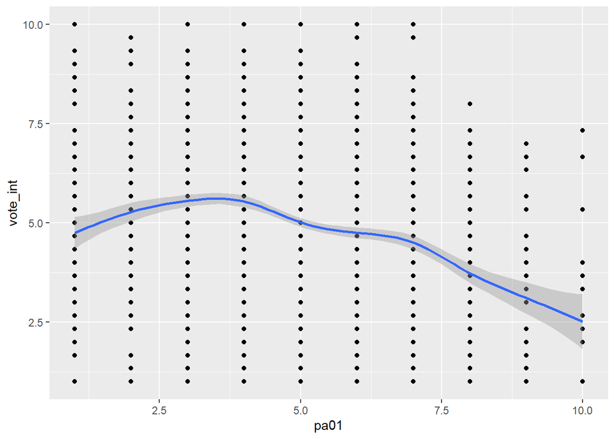

```r
### calls the plots
# simple scatter plot
exer_22_plot_1
```

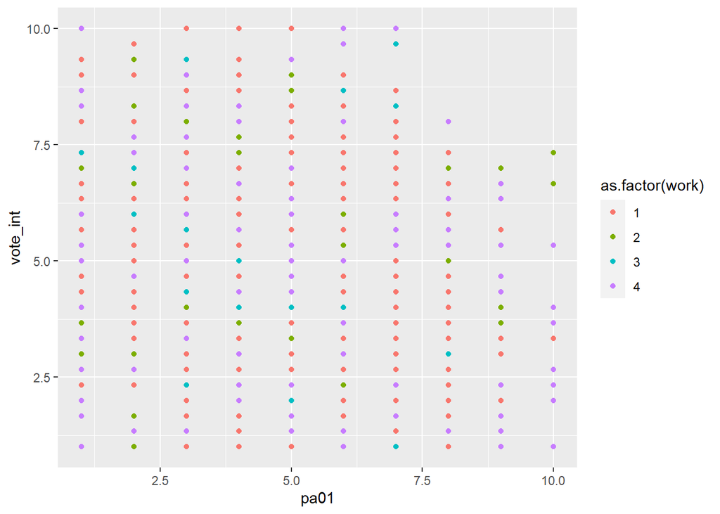

```r
# with added grouping variable
exer_22_plot_2
```

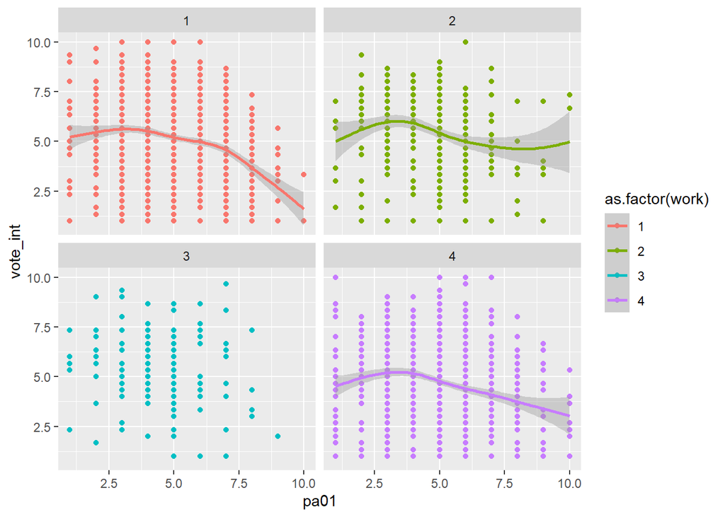

```r
# with split panel plot
exer_22_plot_3
```